# Hito2_pruebas

Eva Cantín Larumbe

13/5/2022

# 1. Lectura datos

```r
vendidas = read.csv("C:/Users/EvaCantin/Desktop/UNI/SEGUNDO/PROYECTO/Valencia Ciudad/Limpieza y Descriptivo R/viviendas_vendidas.csv", sep=";",row.names = 1, as.is=TRUE, encoding='UTF-8')
```

# 2. Análisis exploratorio de los datos y limpieza

## 2.1 Eliminación de variables

```r
vendidas = vendidas[,setdiff(colnames(vendidas), c("ad_condition_isGoodCondition", "ad_operation",  "address_location", "date_insert", "date_update", "latitude", "longitude", "price", "url", "date_last", "features" ,"day_insert", "day_last", "vendido", "ad_characteristics_hasParking"))]

colnames(vendidas)= c('baños', 'm2', 'jardin', 'ascensor', 'piscina', 'terraza', 'habitaciones', 'a_reformar', 'tipo_vendedor', 'tipo_vivienda', 'precio_final', 'distrito', 'barrio', "armarios.empotrados", "acceso.adaptado", "aire.acondicionado", "balcon", "trastero", "garaje.incluido", "calefaccion", "planta", "vistas", "variacion_precio", "dias_venta")
```

## 2.2 Exploración de Variables y Observaciones

Vamos a ver cuántos inmuebles hay de cada tipo. 1:pisos, 2:casas y 10:obras nuevas

```r
table(vendidas$tipo_vivienda)
```

```
##
##    1    2   10
## 2325   74   79
```

> 2325/2478*100 –> 93.82567% 74/2478*100 –> 2.986279% 79/2478*100 –> 3.188055%

Vamos a ver en qué distritos se encuentran las casas y las obras nuevas.

```r
table(vendidas$distrito[vendidas$tipo_vivienda==2])
```

```
##
##          algirós        benicalap       benimaclet         campanar
##                1                2                3                8
##        extramurs            jesús poblats marítims pobles de l'oest
##                1                1               28                6
##  pobles del nord   pobles del sud  quatre carreres         rascanya
##                1                7                8                8
```

```r
table(vendidas$distrito[vendidas$tipo_vivienda==10])
```

```
##
##          algirós        benicalap       benimaclet   camins al grau
##                2                5                1                3
##         campanar     ciutat vella        extramurs            jesús
##                6                1                1                3
##       l'eixample      l'olivereta        la saïdia          patraix
##                3                6                3               10
## poblats marítims pobles de l'oest  pobles del nord   pobles del sud
##                3                1                1                4
##  quatre carreres         rascanya
##               23                3
```

Como 28 de 74 casas (37,83%), se encuentran en Poblats Marítims (son casas modestas, de pescadores), hemos decidido excluir las casas del análisis.

En el casa de las obras nuevas, al ser un 3,188% del total de viviendas y la distribución por distritos es más parecida, también vamos a eliminarlas del estudio.

```r
casas = which(vendidas$tipo_vivienda==2)
nuevas = which(vendidas$tipo_vivienda==10)
vendidas = vendidas[-casas, ]
vendidas = vendidas[-nuevas, ]
```

Como ahora la variable tipo_vivienda es constante, (tipo_vivienda=1), la eliminamos de la BD.

```r
borrar = c("tipo_vivienda")
vendidas = vendidas[ , !(names(vendidas) %in% borrar)]
```

### 2.2.1 BAÑOS, HABITACIONES Y M2

A continuación, vamos a hacer una exploración de las variables “Baños”; “Habitaciones” y “M2”. Si una casa no tiene ni baños, ni habitaciones ni M2, la eliminaremos de la BD, ya que consideramos que estas tres varaibles son **fundamentales** para el análisis inmobiliario.

Por otro lado, vamos a ver si hay valores anómalos en dichas variables.

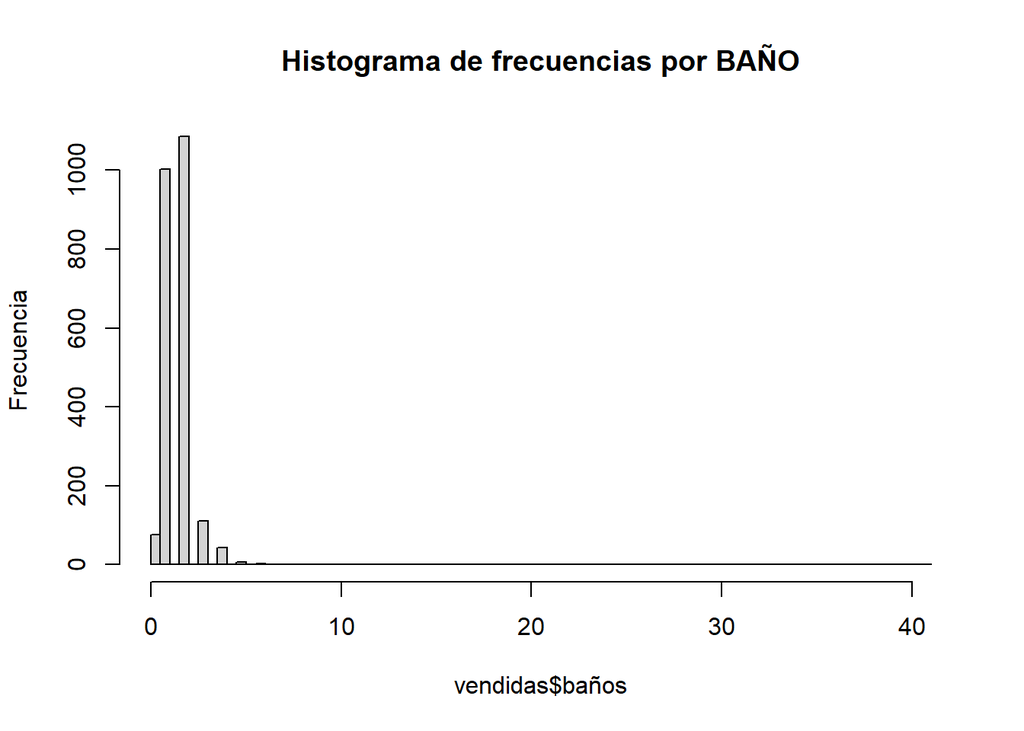

```r
#ver cuántos baños tenemos a 0
hist(vendidas$baños, main = "Histograma de frecuencias por BAÑO",
     ylab = "Frecuencia", breaks=100)
```

```r
#Número máximo de baños --> 41
max(vendidas$baños, na.rm=TRUE)
```

```
## [1] 41
```

```r
#Ver cuántos pisos no tienen baños --> 76 pisos
sum(vendidas$baños==0, na.rm=TRUE)
```

```
## [1] 76
```

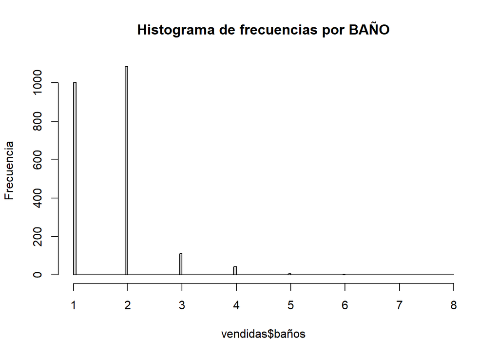

```r
nulos = which(vendidas$baños==0)
vendidas$baños[vendidas$baños== 41] = 1

vendidas = vendidas[-nulos, ]

hist(vendidas$baños, main = "Histograma de frecuencias por BAÑO",
     ylab = "Frecuencia", breaks=100)
```

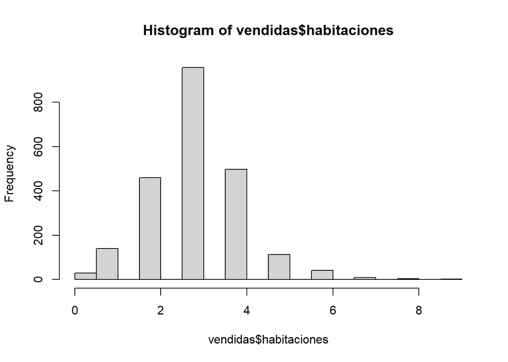

```r
#HABITACIONES
hist(vendidas$habitaciones)
```

```r
sum(vendidas$habitaciones == 0, na.rm=TRUE)
```

```
## [1] 30
```

```r
quitar = which(vendidas$habitaciones == 0)
vendidas = vendidas[-quitar, ]
prec_quitar = which(vendidas$precio == 0)
```

Hemos observado que hay un piso con 41 baños y 85m2. Como consideramos esto un **error**, y lo más probable es que tenga 1 baño, lo hemos corregido.

Por otra parte, hemos visto que hay 76 pisos sin baño, pero también hemos comprobado que estos pisos tampoco tienen el número de habitaciones y los m2. Por ello, se eliminan estos 76 individuos.

En cuanto al número de habitaciones, sigue habiendo 30 pisos sin él. Se han eliminado estos pisos también.

Por último, hemos estudiado si había algún piso sin el precio de venta. Como hemos visto que esta condición NO se cumple, no hemos eliminado ninguna observación.

### 2.2.2 DIAS_VENTA

Respecto a la variable “Dias_venta”, se ha llevado a cabo un pequeño proceso de transformación. Esta variable inicialmente era una cadena de caracteres (String) con el siguiente formato: ‘num + days’.

El proceso de transformación ha consistido en eliminar la palabra ‘days’ y convertir el número a un entero (int).

Finalmente, si algún piso tenía un número negativo de días de venta, lo hemos corregido a 0, puesto que lo hemos considerado un error y creemos que es una solución coherente.

```r
vendidas$dias_venta = gsub(" days", "", vendidas$dias_venta)
vendidas = transform(vendidas, dias_venta = as.numeric(dias_venta))

# Ponemos a 0 los días_venta a aquellos pisos que tengan días negativos
vendidas$dias_venta[vendidas$dias_venta < 0] = 0
```

## 2.3 Transformación y recodificación de variables

si queremos incluir una variable categórica en un modelo que solo acepta variables numéricas, podemos recodificar la variable categórica a variables numéricas 0-1 y así ya la podríamos incluir en dicho modelo.

En nuestro caso, la variable vistas es una variable binaria que tiene 2 categorías: “exterior” e “interior”. Con el fin de convertirla a binaria numérica, vamos a codificar **“exterior” a 1** e **“interior” a 0**.

```r
# a binarias: vistas (interior = 0, exterior = 1)
vendidas$vistas[vendidas$vistas == 'exterior'] = 1
vendidas$vistas[vendidas$vistas == 'interior'] = 0
vendidas$vistas[vendidas$vistas == ''] = NA
vendidas$vistas[vendidas$vistas == 'TRUE'] = NA
vendidas$vistas[vendidas$vistas == 'FALSE'] = NA
```

## 2.4 Valores faltantes. Imputación.

Generaremos en primer lugar una tabla resumen con el número y porcentaje de valores faltantes en cada variable en la base de datos.

```r
descVend = data.frame("variable" = colnames(vendidas),
                      "tipo" = c(rep("numerical", 2), rep("binary", 4), "numerical", rep("binary", 2), "numerical", rep("categorical", 2), rep("binary", 7), "numerical", rep("binary", 1), rep("numerical",2)),stringsAsFactors = FALSE)
rownames(descVend) = descVend$variable
```

```r
library(kableExtra)
numNA = apply(vendidas, 2, function(x) sum(is.na(x)))
percNA = round(100*apply(vendidas, 2, function(x) mean(is.na(x))), 2)
tablaNA = data.frame("tipo" = descVend[,-1], numNA, percNA)
kable(tablaNA, format="latex", booktabs = T) %>% kable_styling()
```

[output not shown]

La solución más viable y por la que nos hemos decantado es imputar estos datos con la librería mice() de R. Imputarlos con la media no nos parece un buen método, ya que sesgaría los resultados.

```r
library(mice)
#convertimos las variables binarias a factores
vendidas[which(descVend$tipo == 'binary')] = lapply(vendidas[which(descVend$tipo == 'binary')], as.factor)
vend = vendidas
vendImp = mice(vend, seed = 123, m = 5, print = FALSE, method = NULL)

head(vendImp$imp$vistas)
```

```
##      1 2 3 4 5
## 1416 1 1 1 1 1
## 1584 1 1 1 1 1
## 1585 1 1 1 1 1
## 1997 1 1 1 0 1
## 2123 1 1 1 0 1
## 2967 0 1 0 1 1
```

```r
vendImp = complete(vendImp) #Complete a data frame with missing combinations of data
```

Tras haber imputado los datos faltantes con la librería mice, vamos a ver cómo han cambiado las variables que tenían datos faltantes (“planta” y “vistas”):

```r
summary(vend$vistas)
```

```
##    0    1 NA's
##   93 1720  408
```

```r
summary(vendImp$vistas)
```

```
##    0    1
##  125 2096
```

```r
summary(vend$planta)
```

```
##    Min. 1st Qu.  Median    Mean 3rd Qu.    Max.    NA's
##   0.000   2.000   3.000   3.587   5.000  18.000     155
```

```r
summary(vendImp$planta)
```

```
##    Min. 1st Qu.  Median    Mean 3rd Qu.    Max.
##   0.000   2.000   3.000   3.578   5.000  18.000
```

```r
numNA = apply(vendImp, 2, function(x) sum(is.na(x)))
percNA = round(100*apply(vendImp, 2, function(x) mean(is.na(x))), 2)
tablaNA = data.frame("tipo" = descVend[,-1], numNA, percNA)

kable(tablaNA, format="latex", booktabs = T) %>% kable_styling()
```

# 3. Exploración de los distritos de los pisos

En primer lugar, realizamos gráficos que puedan mostrarnos el precio según los distritos:

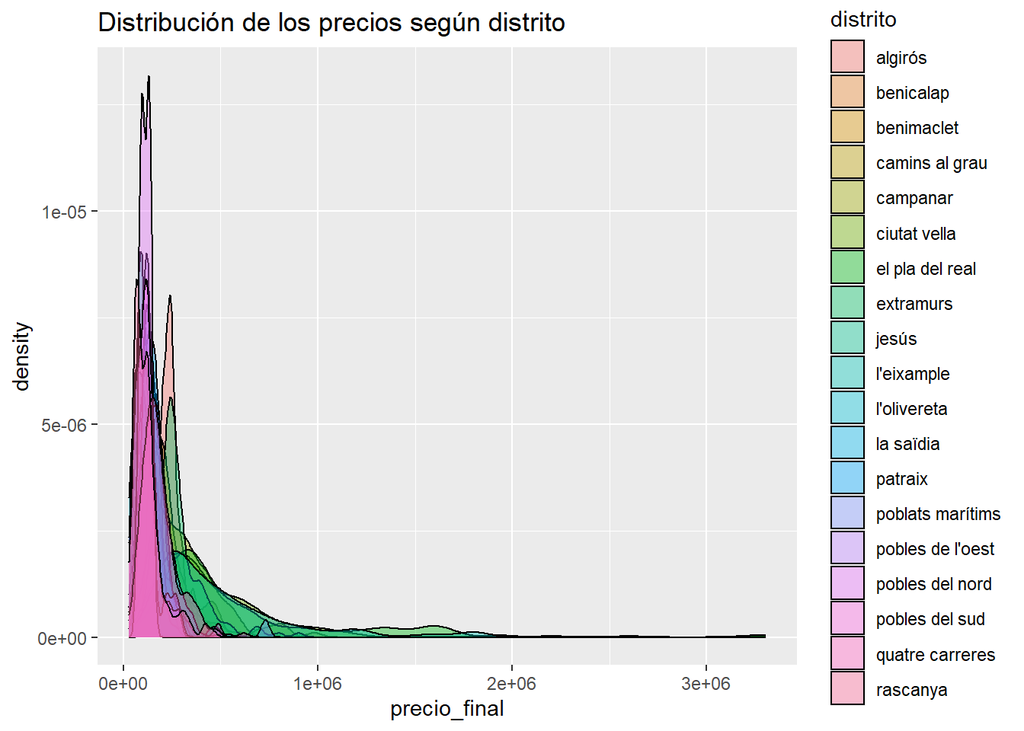

```r
vendidas_distritos = vendImp
ggplot(vendidas_distritos,
       aes(precio_final,
           fill = distrito)) +
  geom_density(alpha = 0.4) +
  labs(title = "Distribución de los precios según distrito")
```

Como la distribución es extremadamente asimétrica positiva, aplicamos logaritmo al eje de las X (precio_final)

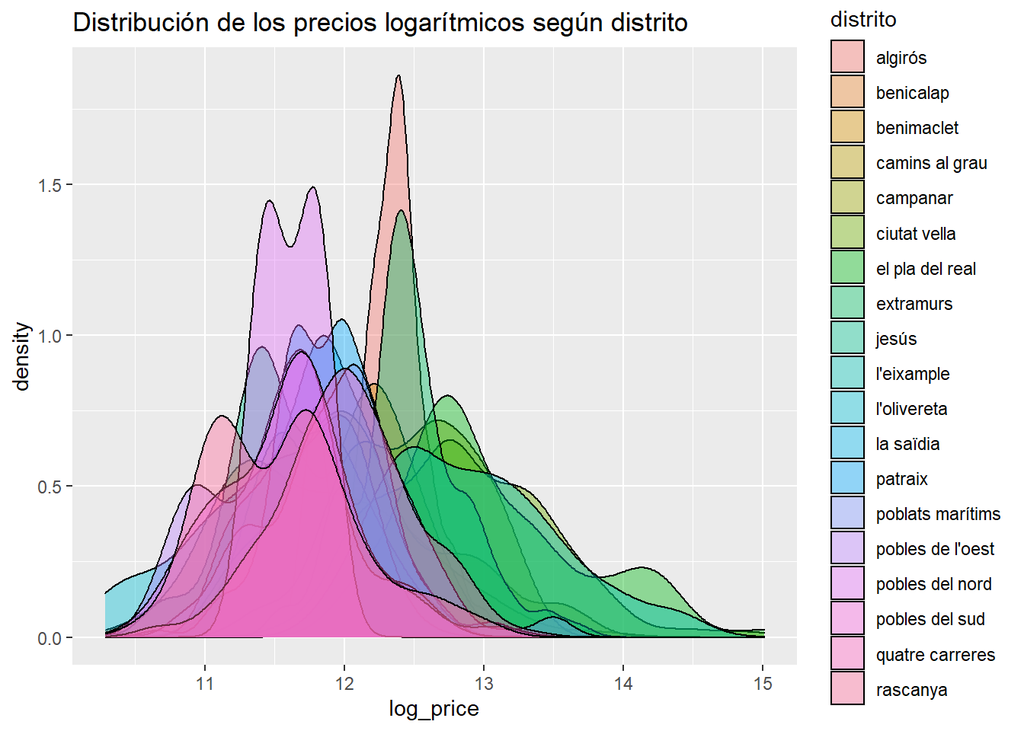

```r
plotdata_logprice <- vendidas_distritos %>%
  group_by(distrito) %>%
  summarise(log_price = log(precio_final))
ggplot(plotdata_logprice,
       aes(log_price,
           fill = distrito)) +
  geom_density(alpha = 0.4) +
  labs(title = "Distribución de los precios logarítmicos según distrito")
```

Ahora realizamos boxplot con los precios de los pisos según distritos:

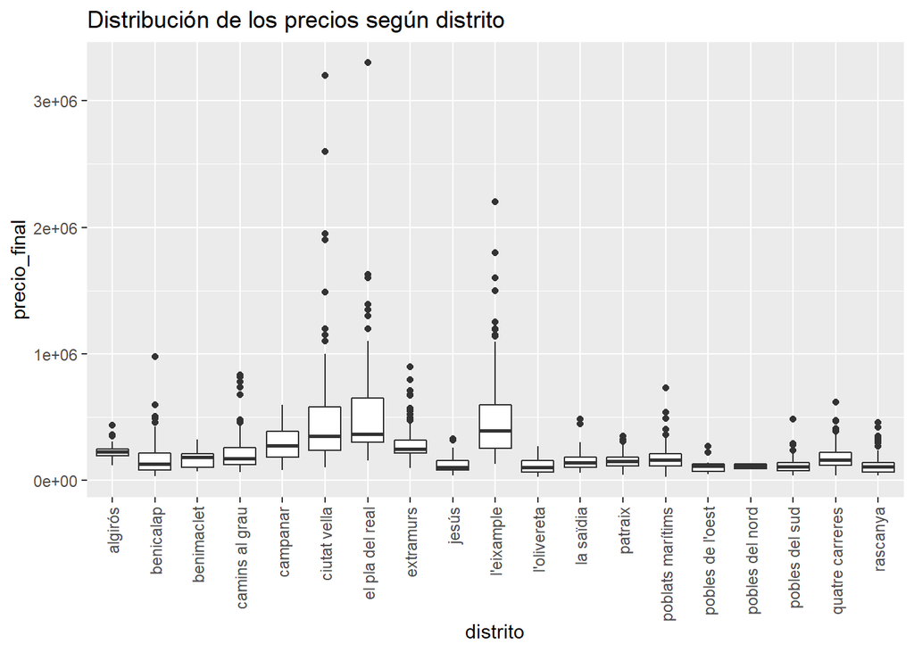

```r
ggplot(vendidas_distritos,
       aes(x = distrito,
           y = precio_final)) + theme(axis.text.x = element_text(angle = 90, vjust = 0.5, hjust=1)) +
  geom_boxplot() +
  labs(title = "Distribución de los precios según distrito")
```

# 4. Exploración del precio_final de los pisos

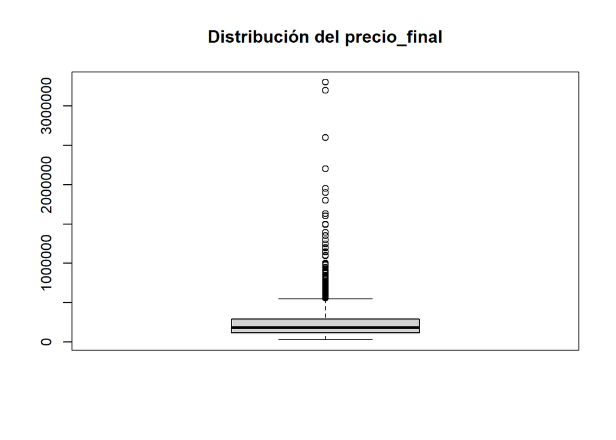

```r
boxplot(vendidas_distritos$precio_final, main = "Distribución del precio_final")
```

```r
summary(vendidas_distritos$precio_final)
```

```
##    Min. 1st Qu.  Median    Mean 3rd Qu.    Max.
##   29300  120000  180000  254593  295000 3300000
```

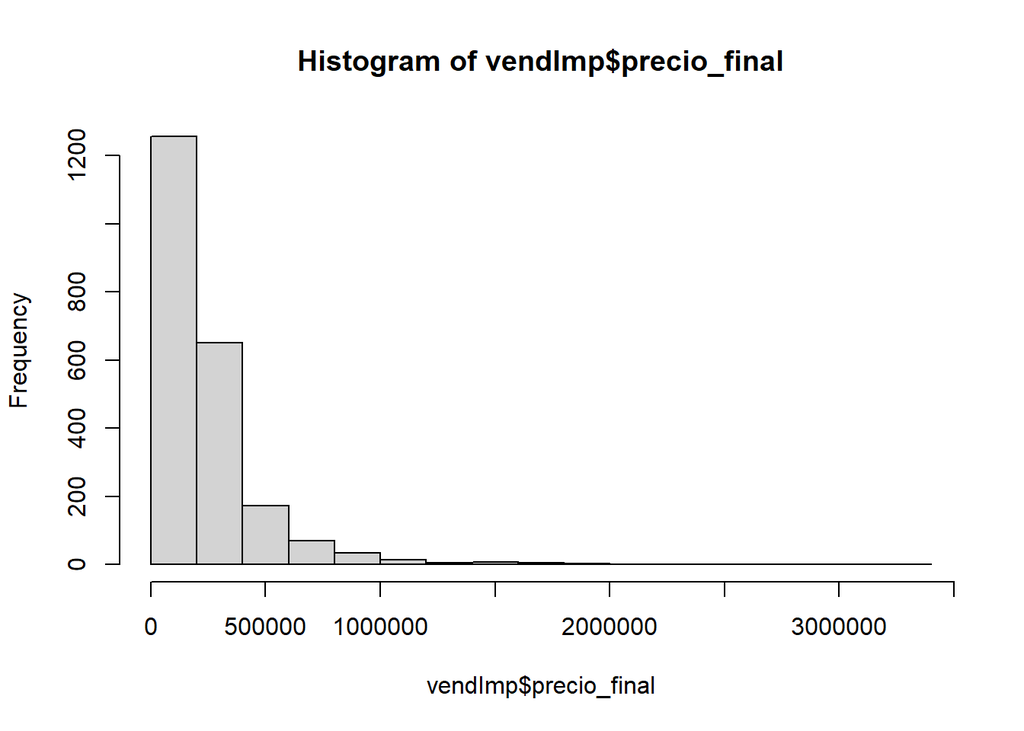

```r
#RANGO INTERCUARTÍLICO
IQR = 295000 - 120000

#UMBRAL SUPERIOR
sup = 120000 + 1.5 * IQR

#UMBRAL INFERIOR
inf = 120000 - 1.5 *IQR

hist(vendImp$precio_final)
```

## 4.1 Transformaciones: logaritmo y raíz cúbica

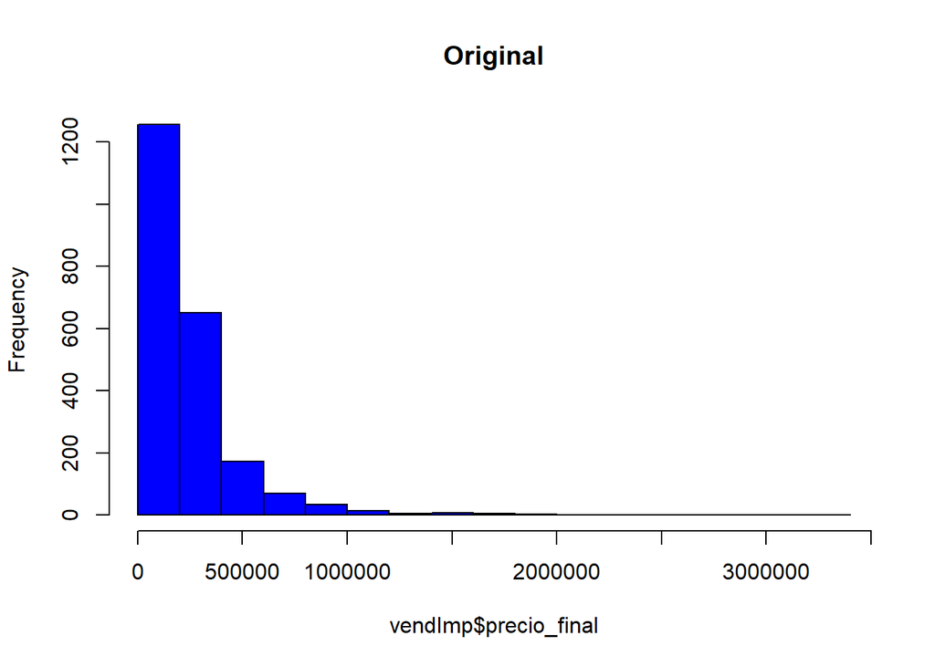

```r
log_precio=log(vendImp$precio_final)
hist (vendImp$precio_final, col = 'blue', main = 'Original')
```

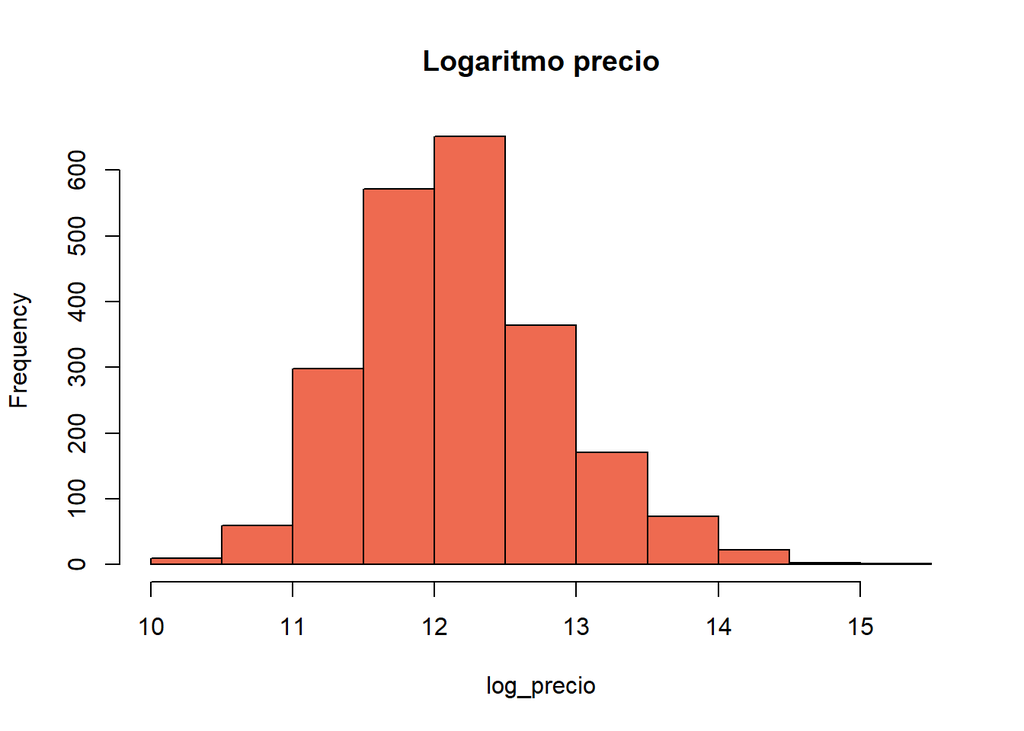

```r
hist(log_precio, col = 'coral2', main = 'Logaritmo precio')
```

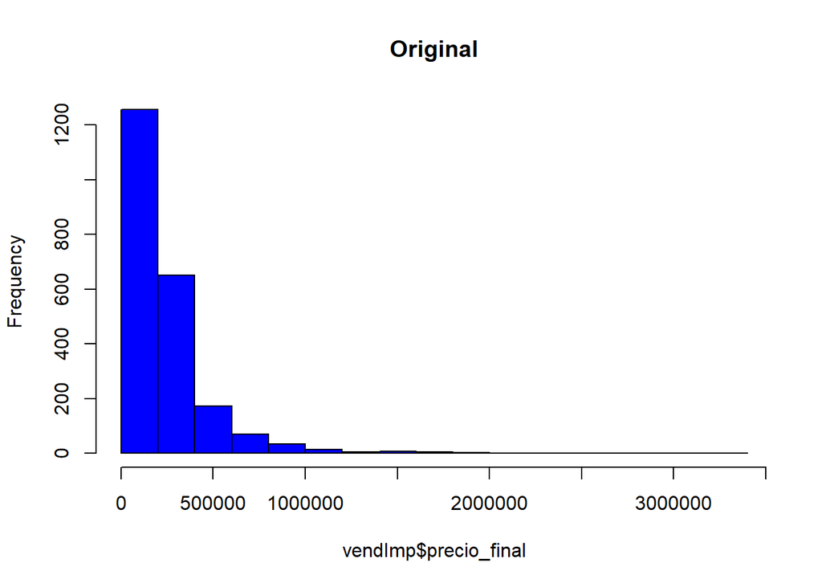

```r
cube_precio=vendImp$precio_final ^ (1/3)
hist (vendImp$precio_final, col = 'blue', main = 'Original')
```

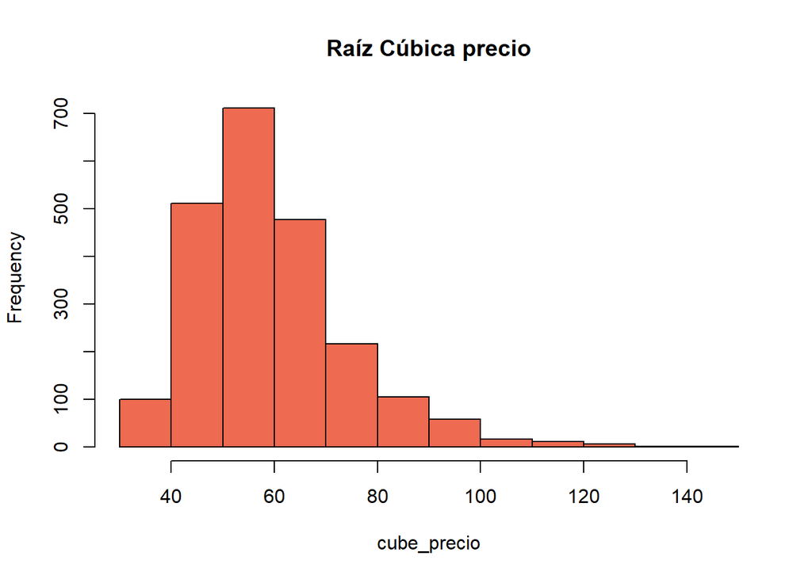

```r
hist(cube_precio, col = 'coral2', main = 'Raíz Cúbica precio')
```

## 4.2 Diferencias entre tipo_vendedor=1 (particular) y tipo_vendedor=2 (inmobiliaria)

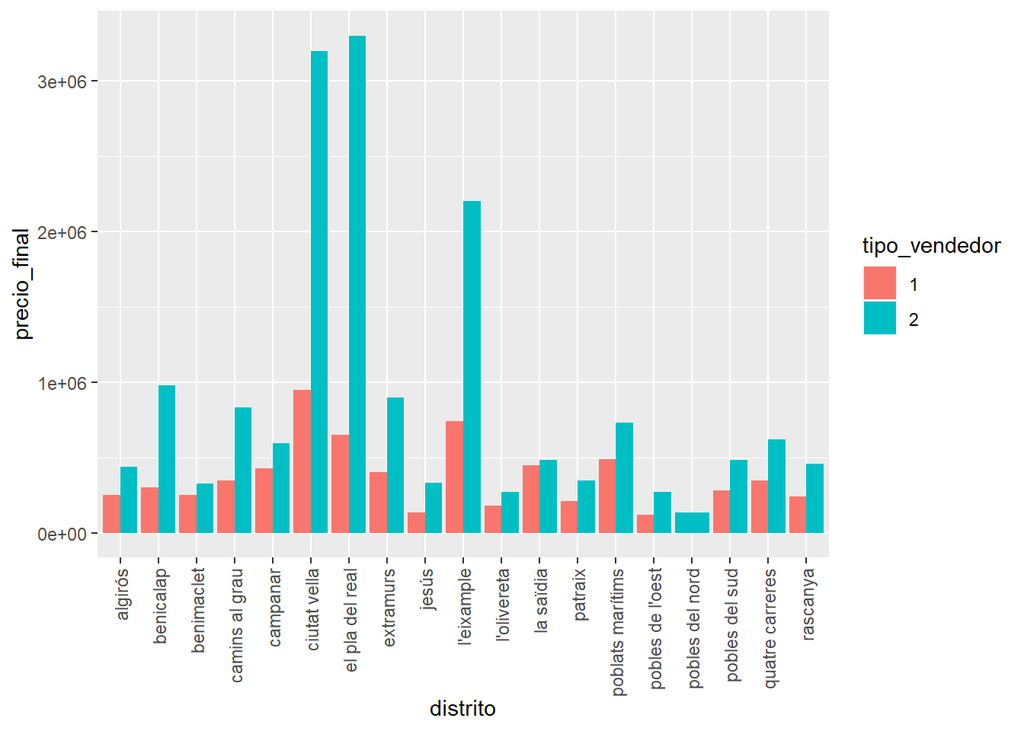

```r
ggplot(vendImp, aes(x=distrito, y=precio_final, fill=tipo_vendedor)) + geom_col(position = "dodge") + theme(axis.text.x = element_text(angle = 90, vjust = 0.5, hjust=1))
```

Como podemos observar en este gráfico de barras agrupadas, hay 3 distritos en los que hay una gran diferencia entre los pisos vendidos por inmobiliarias y particulares. Estos distritos son Ciutat Vella, El pla del Real y L’Eixample. Vamos a ver qué ocurre con estos distritos.

```r
ciutat_vella= vendImp[vendImp$distrito == "ciutat vella",]
pla_real=vendImp[vendImp$distrito=="el pla del real",]
eixample=vendImp[vendImp$distrito=="l'eixample",]

dif = rbind(ciutat_vella, pla_real, eixample)
```

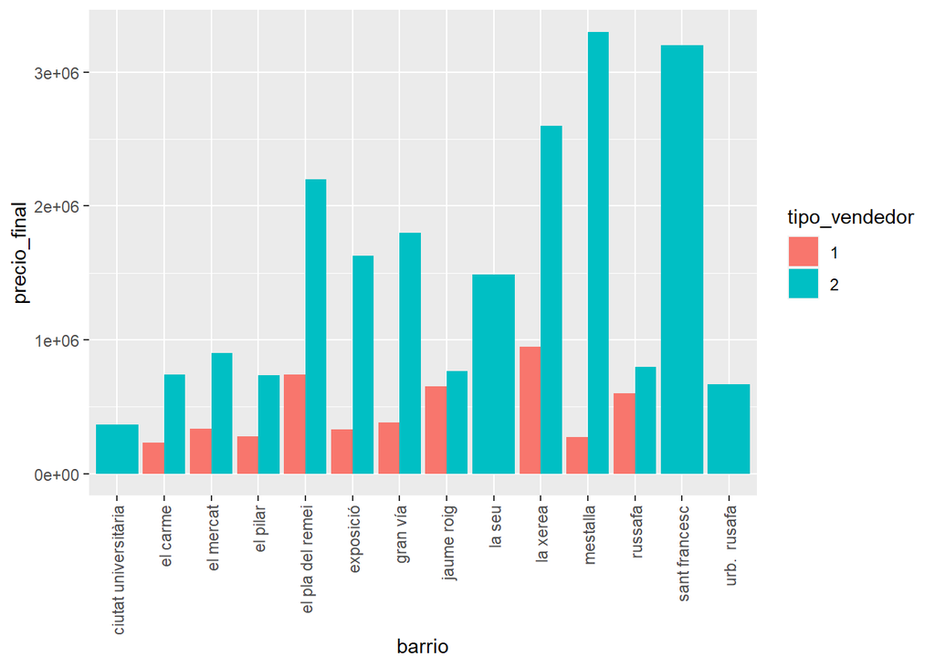

```r
ggplot(dif, aes(x=barrio, y=precio_final, fill=tipo_vendedor)) + geom_col(position = "dodge") + theme(axis.text.x = element_text(angle = 90, vjust = 0.5, hjust=1))
```

```r
kable(t(summary(ciutat_vella[ciutat_vella$tipo_vendedor==1,]))) %>% kable_styling(font_size=8)  #particular
```

| baños | Min. :1.0 | 1st Qu.:1.0 | Median :2.0 | Mean :1.8 | 3rd Qu.:2.0 | Max. :3.0 |
| --- | --- | --- | --- | --- | --- | --- |
| m2 | Min. : 70 | 1st Qu.: 95 | Median :113 | Mean :146 | 3rd Qu.:152 | Max. :300 |
| jardin | 0:5 | 1:0 | NA | NA | NA | NA |
| ascensor | 0:2 | 1:3 | NA | NA | NA | NA |
| piscina | 0:5 | 1:0 | NA | NA | NA | NA |
| terraza | 0:4 | 1:1 | NA | NA | NA | NA |
| habitaciones | Min. :1 | 1st Qu.:2 | Median :3 | Mean :3 | 3rd Qu.:4 | Max. :5 |
| a_reformar | 0:5 | 1:0 | NA | NA | NA | NA |
| tipo_vendedor | 1:5 | 2:0 | NA | NA | NA | NA |
| precio_final | Min. :149000 | 1st Qu.:232000 | Median :279900 | Mean :388980 | 3rd Qu.:334000 | Max. :950000 |
| distrito | Length:5 | Class :character | Mode :character | NA | NA | NA |
| barrio | Length:5 | Class :character | Mode :character | NA | NA | NA |
| armarios.empotrados | 0:2 | 1:3 | NA | NA | NA | NA |
| acceso.adaptado | 0:4 | 1:1 | NA | NA | NA | NA |
| aire.acondicionado | 0:2 | 1:3 | NA | NA | NA | NA |
| balcon | 0:2 | 1:3 | NA | NA | NA | NA |
| trastero | 0:2 | 1:3 | NA | NA | NA | NA |
| garaje.incluido | 0:5 | 1:0 | NA | NA | NA | NA |
| calefaccion | 0:2 | 1:3 | NA | NA | NA | NA |
| planta | Min. :0.0 | 1st Qu.:1.0 | Median :4.0 | Mean :3.6 | 3rd Qu.:6.0 | Max. :7.0 |
| vistas | 0:0 | 1:5 | NA | NA | NA | NA |
| variacion_precio | Min. :-8000 | 1st Qu.: 0 | Median : 0 | Mean :-1600 | 3rd Qu.: 0 | Max. : 0 |
| dias_venta | Min. : 0.0 | 1st Qu.: 0.0 | Median :28.0 | Mean :16.8 | 3rd Qu.:28.0 | Max. :28.0 |

```r
kable(t(summary(ciutat_vella[ciutat_vella$tipo_vendedor==2,]))) %>% kable_styling(font_size=8) #inmobiliaria
```

| baños | Min. :1.000 | 1st Qu.:1.000 | Median :2.000 | Mean :2.014 | 3rd Qu.:2.000 | Max. :8.000 |
| --- | --- | --- | --- | --- | --- | --- |
| m2 | Min. : 40.0 | 1st Qu.: 93.0 | Median :144.0 | Mean :151.5 | 3rd Qu.:183.0 | Max. :750.0 |
| jardin | 0:217 | 1: 4 | NA | NA | NA | NA |
| ascensor | 0: 40 | 1:181 | NA | NA | NA | NA |
| piscina | 0:219 | 1: 2 | NA | NA | NA | NA |
| terraza | 0:161 | 1: 60 | NA | NA | NA | NA |
| habitaciones | Min. :1.000 | 1st Qu.:2.000 | Median :3.000 | Mean :3.389 | 3rd Qu.:5.000 | Max. :9.000 |
| a_reformar | 0:181 | 1: 40 | NA | NA | NA | NA |
| tipo_vendedor | 1: 0 | 2:221 | NA | NA | NA | NA |
| precio_final | Min. : 106000 | 1st Qu.: 240000 | Median : 350000 | Mean : 468082 | 3rd Qu.: 585000 | Max. :3200000 |
| distrito | Length:221 | Class :character | Mode :character | NA | NA | NA |
| barrio | Length:221 | Class :character | Mode :character | NA | NA | NA |
| armarios.empotrados | 0: 71 | 1:150 | NA | NA | NA | NA |
| acceso.adaptado | 0:179 | 1: 42 | NA | NA | NA | NA |
| aire.acondicionado | 0: 82 | 1:139 | NA | NA | NA | NA |
| balcon | 0:122 | 1: 99 | NA | NA | NA | NA |
| trastero | 0:180 | 1: 41 | NA | NA | NA | NA |
| garaje.incluido | 0:185 | 1: 36 | NA | NA | NA | NA |
| calefaccion | 0: 56 | 1:165 | NA | NA | NA | NA |
| planta | Min. : 0.000 | 1st Qu.: 2.000 | Median : 3.000 | Mean : 3.516 | 3rd Qu.: 5.000 | Max. :10.000 |
| vistas | 0: 7 | 1:214 | NA | NA | NA | NA |
| variacion_precio | Min. :-100000 | 1st Qu.: 0 | Median : 0 | Mean : -1447 | 3rd Qu.: 0 | Max. : 25000 |
| dias_venta | Min. : 0.00 | 1st Qu.:16.00 | Median :28.00 | Mean :25.29 | 3rd Qu.:28.00 | Max. :51.00 |

```r
kable(t(summary(pla_real[pla_real$tipo_vendedor==1,]))) %>% kable_styling(font_size=8)  #particular
```

| baños | Min. :2.000 | 1st Qu.:2.000 | Median :2.000 | Mean :2.167 | 3rd Qu.:2.000 | Max. :3.000 |
| --- | --- | --- | --- | --- | --- | --- |
| m2 | Min. : 93.0 | 1st Qu.:122.2 | Median :137.5 | Mean :148.5 | 3rd Qu.:166.2 | Max. :230.0 |
| jardin | 0:4 | 1:2 | NA | NA | NA | NA |
| ascensor | 0:0 | 1:6 | NA | NA | NA | NA |
| piscina | 0:6 | 1:0 | NA | NA | NA | NA |
| terraza | 0:1 | 1:5 | NA | NA | NA | NA |
| habitaciones | Min. :2.000 | 1st Qu.:3.250 | Median :4.000 | Mean :3.667 | 3rd Qu.:4.000 | Max. :5.000 |
| a_reformar | 0:4 | 1:2 | NA | NA | NA | NA |
| tipo_vendedor | 1:6 | 2:0 | NA | NA | NA | NA |
| precio_final | Min. :175000 | 1st Qu.:288750 | Median :340000 | Mean :355000 | 3rd Qu.:350000 | Max. :650000 |
| distrito | Length:6 | Class :character | Mode :character | NA | NA | NA |
| barrio | Length:6 | Class :character | Mode :character | NA | NA | NA |
| armarios.empotrados | 0:1 | 1:5 | NA | NA | NA | NA |
| acceso.adaptado | 0:2 | 1:4 | NA | NA | NA | NA |
| aire.acondicionado | 0:1 | 1:5 | NA | NA | NA | NA |
| balcon | 0:3 | 1:3 | NA | NA | NA | NA |
| trastero | 0:3 | 1:3 | NA | NA | NA | NA |
| garaje.incluido | 0:1 | 1:5 | NA | NA | NA | NA |
| calefaccion | 0:2 | 1:4 | NA | NA | NA | NA |
| planta | Min. :1.000 | 1st Qu.:1.750 | Median :5.000 | Mean :4.833 | 3rd Qu.:7.500 | Max. :9.000 |
| vistas | 0:0 | 1:6 | NA | NA | NA | NA |
| variacion_precio | Min. :-6000 | 1st Qu.: 0 | Median : 0 | Mean :-1000 | 3rd Qu.: 0 | Max. : 0 |
| dias_venta | Min. : 0.00 | 1st Qu.:14.00 | Median :24.00 | Mean :26.67 | 3rd Qu.:43.75 | Max. :51.00 |

```r
kable(t(summary(pla_real[pla_real$tipo_vendedor==2,]))) %>% kable_styling(font_size=8) #inmobiliaria
```

| baños | Min. :1.000 | 1st Qu.:2.000 | Median :2.000 | Mean :2.533 | 3rd Qu.:3.000 | Max. :5.000 |
| --- | --- | --- | --- | --- | --- | --- |
| m2 | Min. : 83.0 | 1st Qu.:116.0 | Median :149.0 | Mean :184.8 | 3rd Qu.:235.5 | Max. :418.0 |
| jardin | 0:72 | 1: 3 | NA | NA | NA | NA |
| ascensor | 0: 2 | 1:73 | NA | NA | NA | NA |
| piscina | 0:74 | 1: 1 | NA | NA | NA | NA |
| terraza | 0:35 | 1:40 | NA | NA | NA | NA |
| habitaciones | Min. :2.000 | 1st Qu.:3.000 | Median :4.000 | Mean :3.827 | 3rd Qu.:4.000 | Max. :7.000 |
| a_reformar | 0:69 | 1: 6 | NA | NA | NA | NA |
| tipo_vendedor | 1: 0 | 2:75 | NA | NA | NA | NA |
| precio_final | Min. : 160000 | 1st Qu.: 307500 | Median : 395000 | Mean : 605711 | 3rd Qu.: 650000 | Max. :3300000 |
| distrito | Length:75 | Class :character | Mode :character | NA | NA | NA |
| barrio | Length:75 | Class :character | Mode :character | NA | NA | NA |
| armarios.empotrados | 0:17 | 1:58 | NA | NA | NA | NA |
| acceso.adaptado | 0:48 | 1:27 | NA | NA | NA | NA |
| aire.acondicionado | 0:16 | 1:59 | NA | NA | NA | NA |
| balcon | 0:47 | 1:28 | NA | NA | NA | NA |
| trastero | 0:61 | 1:14 | NA | NA | NA | NA |
| garaje.incluido | 0:38 | 1:37 | NA | NA | NA | NA |
| calefaccion | 0:15 | 1:60 | NA | NA | NA | NA |
| planta | Min. : 0.000 | 1st Qu.: 3.000 | Median : 5.000 | Mean : 5.267 | 3rd Qu.: 8.000 | Max. :14.000 |
| vistas | 0: 3 | 1:72 | NA | NA | NA | NA |
| variacion_precio | Min. :-50000.0 | 1st Qu.: 0.0 | Median : 0.0 | Mean : -566.7 | 3rd Qu.: 0.0 | Max. : 10000.0 |
| dias_venta | Min. : 0.00 | 1st Qu.:20.00 | Median :28.00 | Mean :29.08 | 3rd Qu.:44.00 | Max. :51.00 |

```r
kable(t(summary(eixample[eixample$tipo_vendedor==1,]))) %>% kable_styling(font_size=8)  #particular
```

| baños | Min. :1.0 | 1st Qu.:1.0 | Median :2.0 | Mean :1.6 | 3rd Qu.:2.0 | Max. :2.0 |
| --- | --- | --- | --- | --- | --- | --- |
| m2 | Min. : 63.0 | 1st Qu.: 76.0 | Median :113.5 | Mean :114.7 | 3rd Qu.:141.0 | Max. :187.0 |
| jardin | 0:9 | 1:1 | NA | NA | NA | NA |
| ascensor | 0:1 | 1:9 | NA | NA | NA | NA |
| piscina | 0:10 | 1: 0 | NA | NA | NA | NA |
| terraza | 0:6 | 1:4 | NA | NA | NA | NA |
| habitaciones | Min. :1.00 | 1st Qu.:2.00 | Median :3.00 | Mean :2.90 | 3rd Qu.:3.75 | Max. :5.00 |
| a_reformar | 0:9 | 1:1 | NA | NA | NA | NA |
| tipo_vendedor | 1:10 | 2: 0 | NA | NA | NA | NA |
| precio_final | Min. :153550 | 1st Qu.:234250 | Median :304000 | Mean :350555 | 3rd Qu.:378750 | Max. :740000 |
| distrito | Length:10 | Class :character | Mode :character | NA | NA | NA |
| barrio | Length:10 | Class :character | Mode :character | NA | NA | NA |
| armarios.empotrados | 0:1 | 1:9 | NA | NA | NA | NA |
| acceso.adaptado | 0:5 | 1:5 | NA | NA | NA | NA |
| aire.acondicionado | 0:2 | 1:8 | NA | NA | NA | NA |
| balcon | 0:3 | 1:7 | NA | NA | NA | NA |
| trastero | 0:9 | 1:1 | NA | NA | NA | NA |
| garaje.incluido | 0:8 | 1:2 | NA | NA | NA | NA |
| calefaccion | 0:5 | 1:5 | NA | NA | NA | NA |
| planta | Min. :1.00 | 1st Qu.:3.25 | Median :4.00 | Mean :3.70 | 3rd Qu.:4.75 | Max. :5.00 |
| vistas | 0:3 | 1:7 | NA | NA | NA | NA |
| variacion_precio | Min. :0 | 1st Qu.:0 | Median :0 | Mean :0 | 3rd Qu.:0 | Max. :0 |
| dias_venta | Min. : 0.00 | 1st Qu.:12.75 | Median :24.00 | Mean :20.30 | 3rd Qu.:28.00 | Max. :44.00 |

```r
kable(t(summary(eixample[eixample$tipo_vendedor==2,]))) %>% kable_styling(font_size=8) #inmobiliaria
```

| baños | Min. :1.000 | 1st Qu.:2.000 | Median :2.000 | Mean :2.049 | 3rd Qu.:2.000 | Max. :5.000 |
| --- | --- | --- | --- | --- | --- | --- |
| m2 | Min. : 30.0 | 1st Qu.:100.0 | Median :137.0 | Mean :151.4 | 3rd Qu.:193.0 | Max. :420.0 |
| jardin | 0:198 | 1: 7 | NA | NA | NA | NA |
| ascensor | 0: 21 | 1:184 | NA | NA | NA | NA |
| piscina | 0:205 | 1: 0 | NA | NA | NA | NA |
| terraza | 0:145 | 1: 60 | NA | NA | NA | NA |
| habitaciones | Min. :1.000 | 1st Qu.:3.000 | Median :4.000 | Mean :3.498 | 3rd Qu.:4.000 | Max. :7.000 |
| a_reformar | 0:169 | 1: 36 | NA | NA | NA | NA |
| tipo_vendedor | 1: 0 | 2:205 | NA | NA | NA | NA |
| precio_final | Min. : 130000 | 1st Qu.: 255000 | Median : 395000 | Mean : 506502 | 3rd Qu.: 599000 | Max. :2200000 |
| distrito | Length:205 | Class :character | Mode :character | NA | NA | NA |
| barrio | Length:205 | Class :character | Mode :character | NA | NA | NA |
| armarios.empotrados | 0: 58 | 1:147 | NA | NA | NA | NA |
| acceso.adaptado | 0:156 | 1: 49 | NA | NA | NA | NA |
| aire.acondicionado | 0: 71 | 1:134 | NA | NA | NA | NA |
| balcon | 0:115 | 1: 90 | NA | NA | NA | NA |
| trastero | 0:173 | 1: 32 | NA | NA | NA | NA |
| garaje.incluido | 0:167 | 1: 38 | NA | NA | NA | NA |
| calefaccion | 0: 66 | 1:139 | NA | NA | NA | NA |
| planta | Min. :0.000 | 1st Qu.:2.000 | Median :4.000 | Mean :3.741 | 3rd Qu.:5.000 | Max. :9.000 |
| vistas | 0: 6 | 1:199 | NA | NA | NA | NA |
| variacion_precio | Min. :-199995 | 1st Qu.: 0 | Median : 0 | Mean : -2590 | 3rd Qu.: 0 | Max. : 0 |
| dias_venta | Min. : 0.00 | 1st Qu.:13.00 | Median :25.00 | Mean :23.85 | 3rd Qu.:28.00 | Max. :51.00 |

```r
df2 = vendImp %>% group_by(tipo_vendedor) %>% summarise(N= n(), media_m2 = mean(m2), media_baños = mean(baños), media_habitaciones = mean(habitaciones), media_precio = mean(precio_final), media_dias_venta = mean(dias_venta), SD_precio = sd(precio_final), min_precio = min(precio_final), max_precio=max(precio_final), porc_jardin = sum(jardin==1)/N*100, porc_ascensor=sum(ascensor==1)/N*100, porc_terraza= sum(terraza==1)/N*100, porc_reformar=sum(a_reformar==1)/N*100, porc_aire = sum(aire.acondicionado==1)/N*100, porc_trastero=sum(trastero==1)/N*100, porc_garaje=sum(garaje.incluido==1)/N*100, porc_calefaccion=sum(calefaccion==1)/N*100, media_planta=mean(planta), porc_exterior=sum(vistas==1)/N*100)

df3 = as.data.frame(t(df2))
colnames(df3) = c("Particular", "Inmobiliaria")
kable(df3, digits=2, format="latex", booktabs = T) %>% kable_styling()
```

```r
#Pisos vendidos INMOBILIAIRA
```

```
#> 2100/6344 -->0.3310214
```

```r
#Pisos vendidos PARTICULAR
```

```
#> 121/452 --> 0.2676991
```

```r
kable(descVend, "latex", booktabs = T) %>% kable_styling()
```

## 4.3 Relación entre el precio final y los complementos

### 4.3.1 Precio y num planta-ascensor

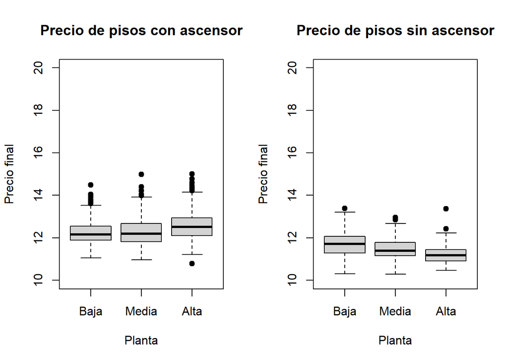

```r
planta_cat=cut(vendImp$planta, breaks = c(0, 2, 4,100), include.lowest = TRUE)
levels(planta_cat) <- c("Baja", "Media", "Alta")
vendImp = cbind(vendImp, planta_cat)
descVend = data.frame("variable" = colnames(vendImp),
                      "tipo" = c(rep("numerical", 2), rep("binary", 4), "numerical", rep("binary", 2), "numerical", rep("categorical", 2), rep("binary", 7), "numerical", rep("binary", 1), rep("numerical",2), "binary"),stringsAsFactors = FALSE)
rownames(descVend) = descVend$variable


te_asc=vendImp$planta_cat[which(vendImp$ascensor==1)]
nte_asc=vendImp$planta_cat[which(vendImp$ascensor==0)]

par (mfrow=c (1,2))
plot(te_asc,log(vendImp$precio_final[which(vendImp$ascensor==1)]),pch = 19, ylim = c (10,20), main = 'Precio de pisos con ascensor', ylab='Precio final',xlab='Planta')
plot(nte_asc,log(vendImp$precio_final[which(vendImp$ascensor==0)]),pch = 19, ylim = c (10,20), main = 'Precio de pisos sin ascensor',ylab='Precio final',xlab='Planta')
```

### 4.3.2 Relación entre el precio y la planta (discretizada)

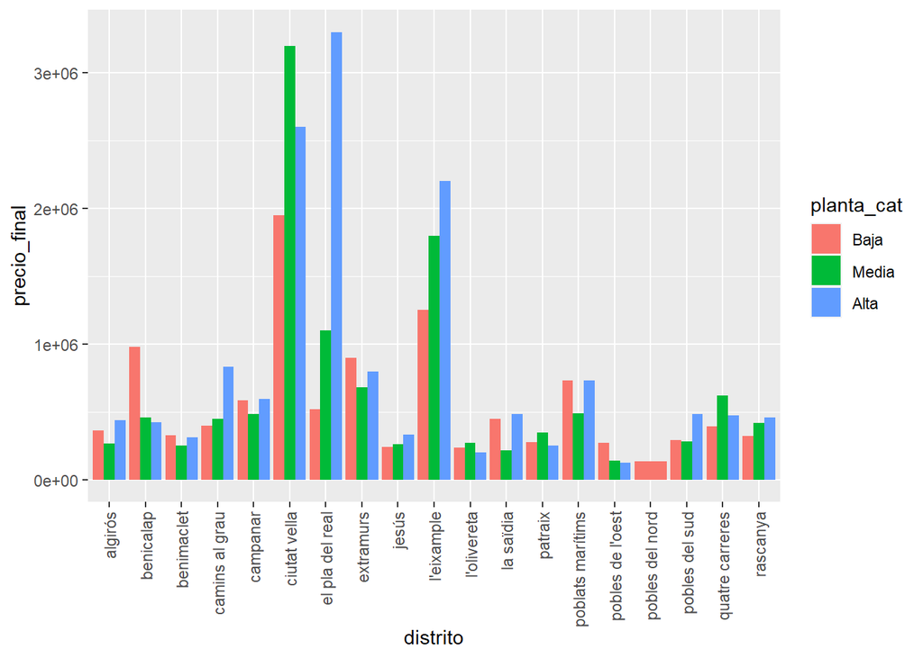

```r
ggplot(vendImp, aes(x=distrito, y=precio_final, fill=planta_cat)) + geom_col(position = "dodge") + theme(axis.text.x = element_text(angle = 90, vjust = 0.5, hjust=1))
```

### 4.3.3 Relación entre el precio y ascensor

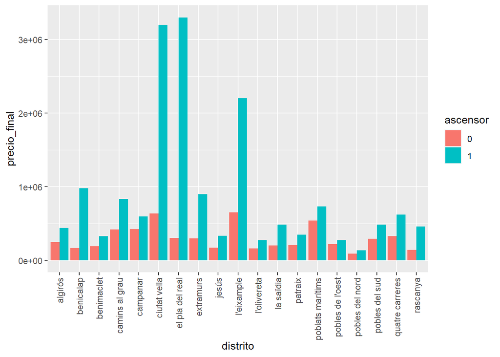

```r
ggplot(vendImp, aes(x=distrito, y=precio_final, fill=ascensor)) + geom_col(position = "dodge") + theme(axis.text.x = element_text(angle = 90, vjust = 0.5, hjust=1))
```

### 4.3.4 Relación entre el precio y jardín

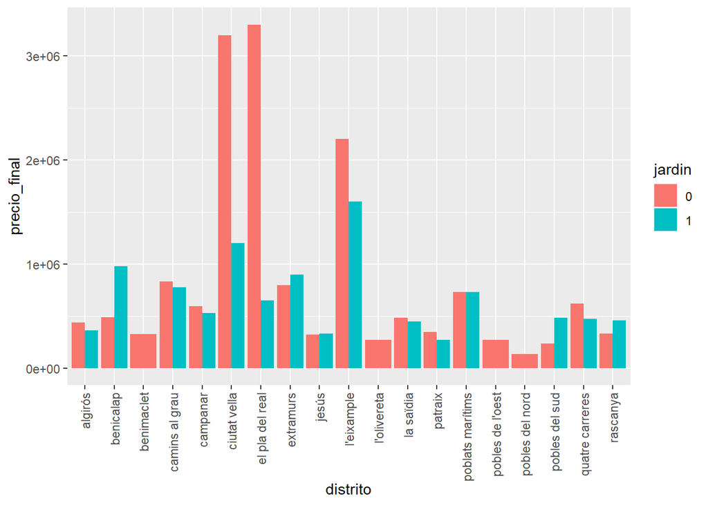

```r
ggplot(vendImp, aes(x=distrito, y=precio_final, fill=jardin)) + geom_col(position = "dodge") + theme(axis.text.x = element_text(angle = 90, vjust = 0.5, hjust=1))
```

### 4.3.5 Relación entre el precio y piscina

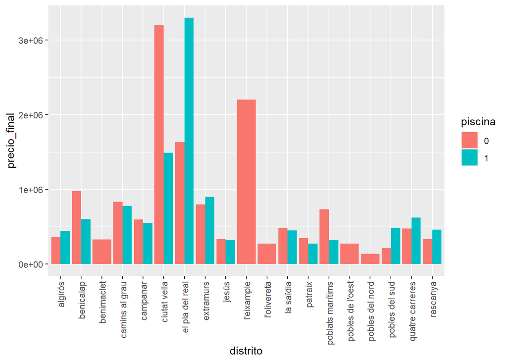

```r
ggplot(vendImp, aes(x=distrito, y=precio_final, fill=piscina)) + geom_col(position = "dodge") + theme(axis.text.x = element_text(angle = 90, vjust = 0.5, hjust=1))
```

### 4.3.6 Relación entre el precio y terraza

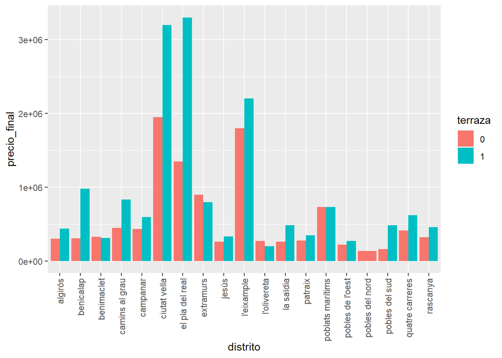

```r
ggplot(vendImp, aes(x=distrito, y=precio_final, fill=terraza)) + geom_col(position = "dodge") + theme(axis.text.x = element_text(angle = 90, vjust = 0.5, hjust=1))
```

### 4.3.7 Relación entre el precio y condición del piso (a_reformar)

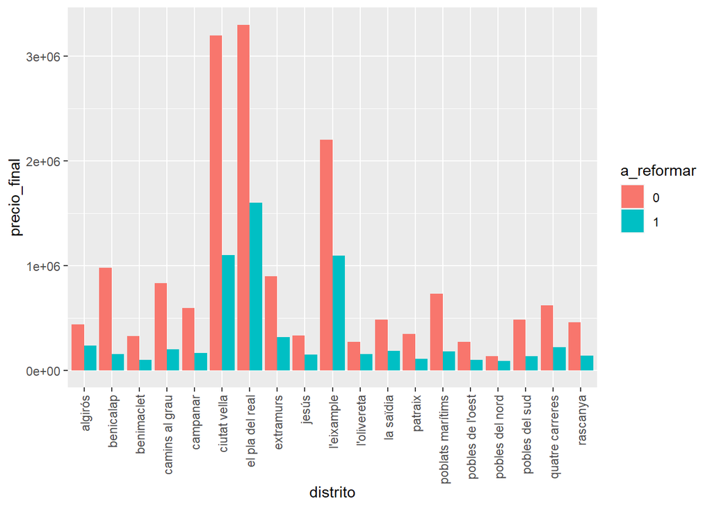

```r
ggplot(vendImp, aes(x=distrito, y=precio_final, fill=a_reformar)) + geom_col(position = "dodge") + theme(axis.text.x = element_text(angle = 90, vjust = 0.5, hjust=1))
```

### 4.3.8 Relación entre el precio y aire acondicionado

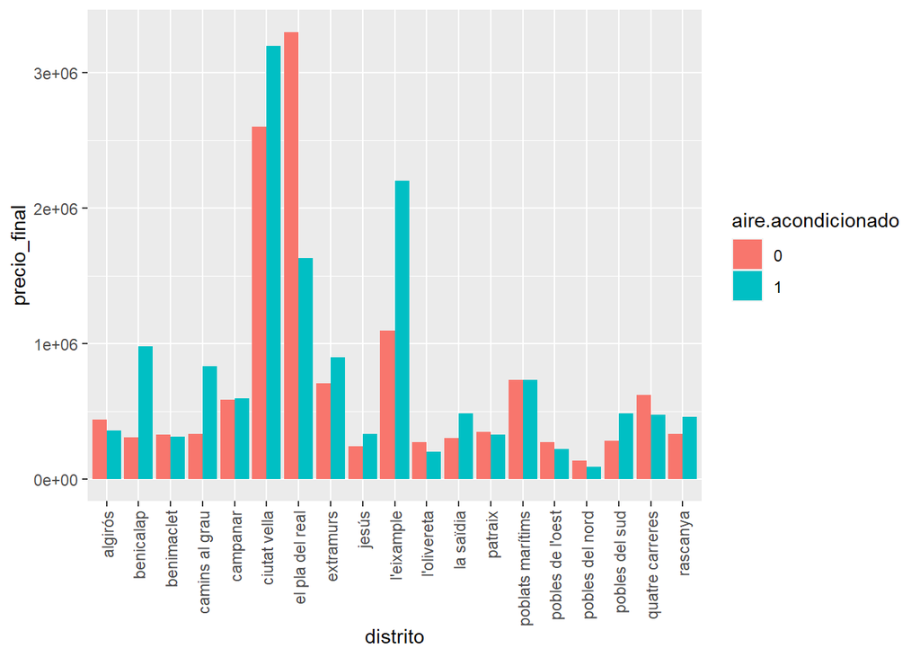

```r
ggplot(vendImp, aes(x=distrito, y=precio_final, fill=aire.acondicionado)) + geom_col(position = "dodge") + theme(axis.text.x = element_text(angle = 90, vjust = 0.5, hjust=1))
```

### 4.3.9 Relación entre el precio y armarios empotrados

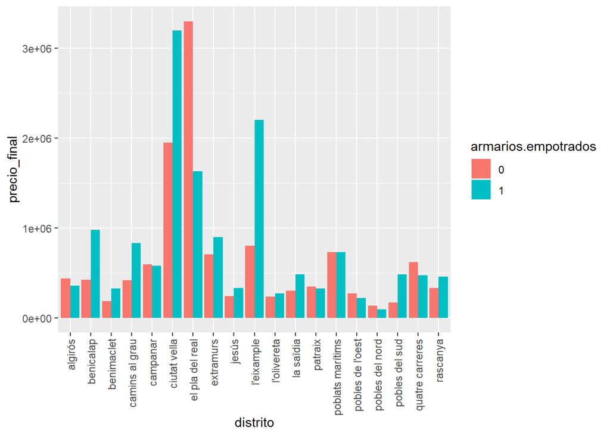

```r
ggplot(vendImp, aes(x=distrito, y=precio_final, fill=armarios.empotrados)) + geom_col(position = "dodge") + theme(axis.text.x = element_text(angle = 90, vjust = 0.5, hjust=1))
```

### 4.3.10 Relación entre el precio y acceso adaptado

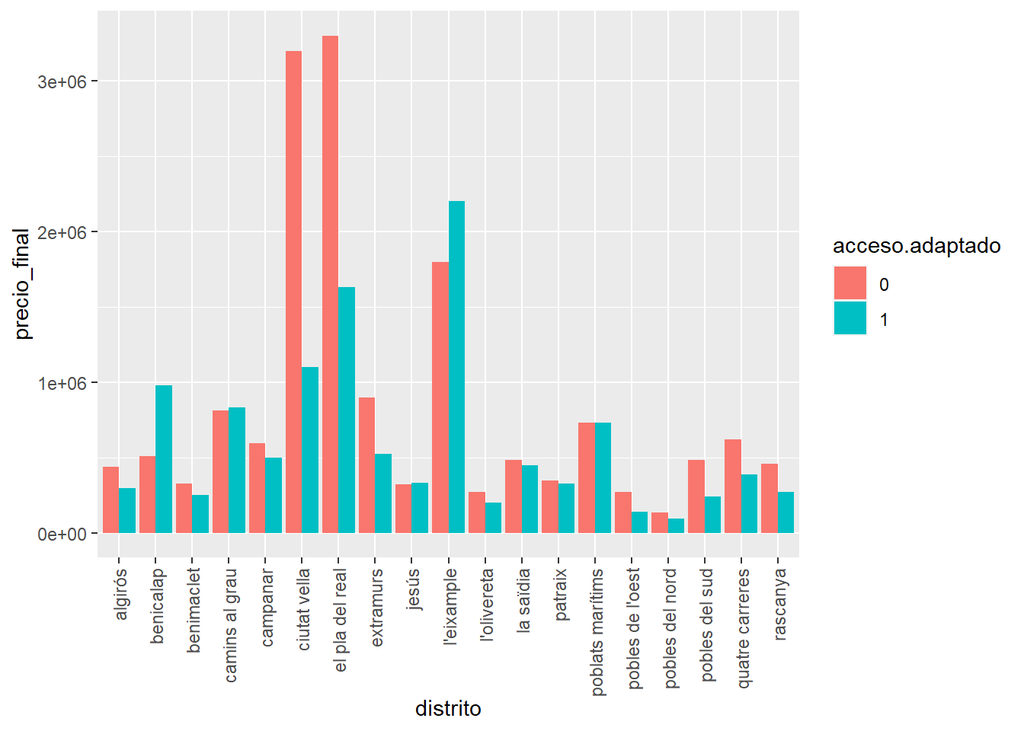

```r
ggplot(vendImp, aes(x=distrito, y=precio_final, fill=acceso.adaptado)) + geom_col(position = "dodge") + theme(axis.text.x = element_text(angle = 90, vjust = 0.5, hjust=1))
```

### 4.3.11 Relación entre el precio y balcón

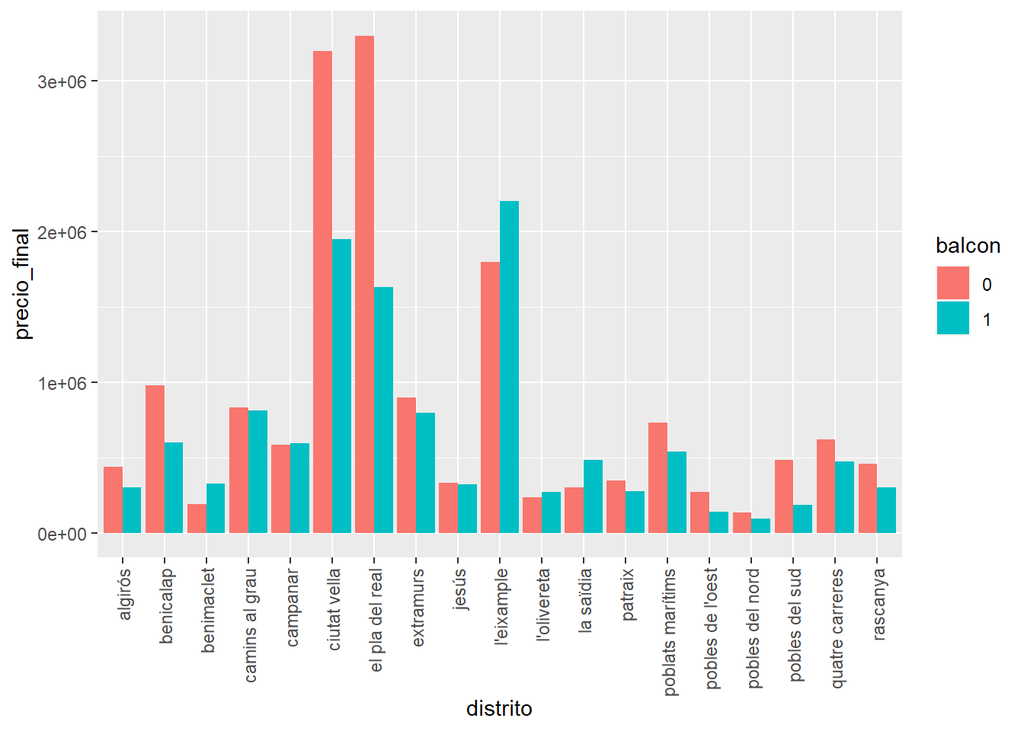

```r
ggplot(vendImp, aes(x=distrito, y=precio_final, fill=balcon)) + geom_col(position = "dodge") + theme(axis.text.x = element_text(angle = 90, vjust = 0.5, hjust=1))
```

### 4.3.12 Relación entre el precio y trastero

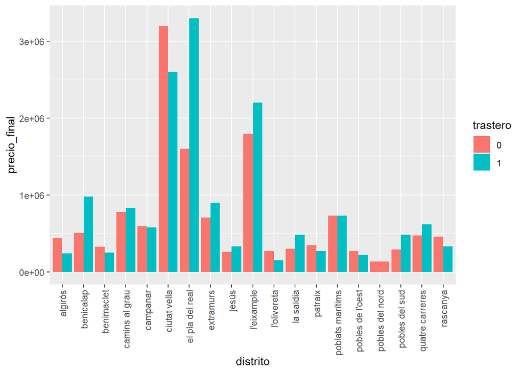

```r
ggplot(vendImp, aes(x=distrito, y=precio_final, fill=trastero)) + geom_col(position = "dodge") + theme(axis.text.x = element_text(angle = 90, vjust = 0.5, hjust=1))
```

### 4.3.13 Relación entre el precio y garaje

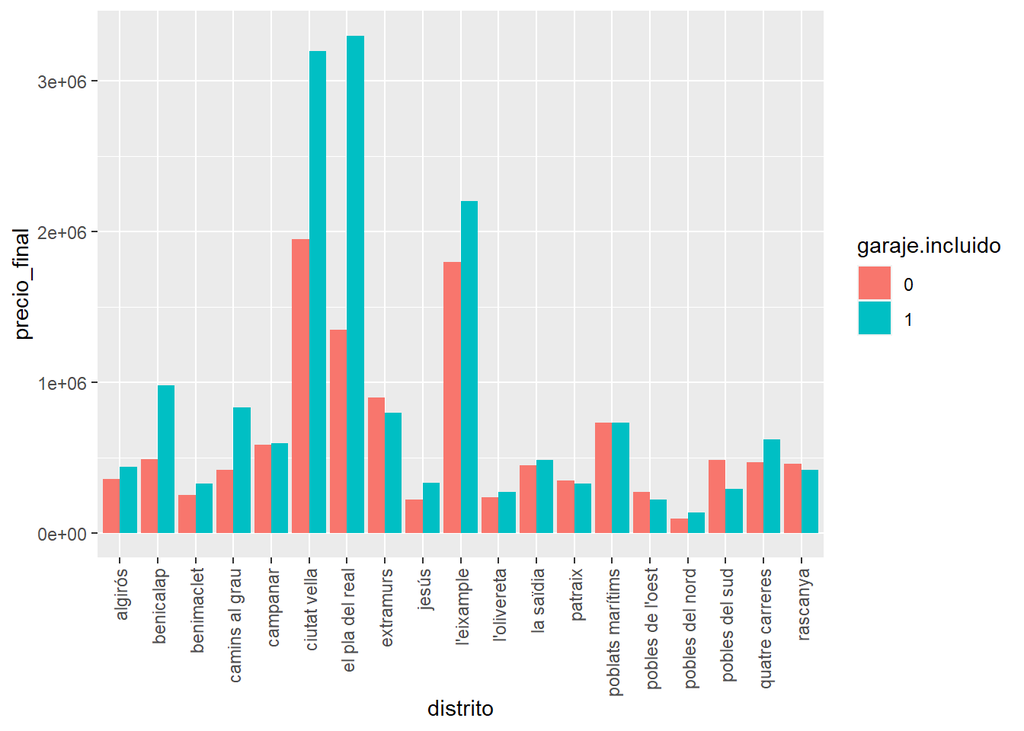

```r
ggplot(vendImp, aes(x=distrito, y=precio_final, fill=garaje.incluido)) + geom_col(position = "dodge") + theme(axis.text.x = element_text(angle = 90, vjust = 0.5, hjust=1))
```

### 4.3.13 Relación entre el precio y calefaccion

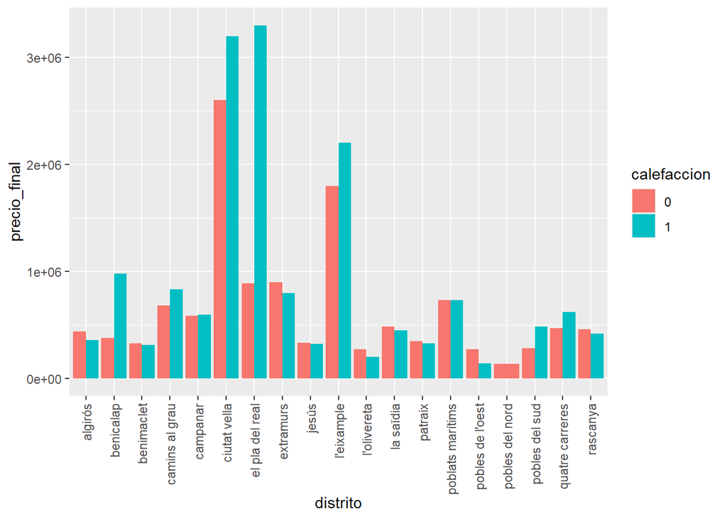

```r
ggplot(vendImp, aes(x=distrito, y=precio_final, fill=calefaccion)) + geom_col(position = "dodge") + theme(axis.text.x = element_text(angle = 90, vjust = 0.5, hjust=1))
```